# Decorrelation-Based Feature Discovery: IR COVID_19

Jose Tamez

2022-10-02

# 1 Effect of UPSTM-Based Decorrelation on Feature Discovery

Here I showcase of to use BSWiMS feature selection/modeling function coupled with Goal Driven Sparse Transformation Matrix (UPSTM) as a pre-processing step to decorrelate highly correlated features. The aim(s) are:

1. To improve model performance by uncovering the hidden information between correlated features.
2. To simplify the interpretation of the machine learning models.

This demo will use:

- *FRESA.CAD::IDeA()*. For Decorrelation of Multidimensional data sets
  - *FRESA.CAD::getLatentCoefficients()*. For the extraction of the model of the newly discovered of decorrelated features.
- *FRESA.CAD::randomCV()* For the cross-validation of the Machine Learning models
- *FRESA.CAD::BSWiMS.model()*. For the generation of bootstrapped logistic models
  - *FRESA.CAD::summary()*. For the summary description of the BSWiMS model
- *FRESA.CAD::predictionStats_binary()*. For describing the performance of the model
- *heatmap.2()*. For displaying the correlation matrix
- *igraph::graph_from_adjacency_matrix()*. For the display of the network of BSWiMS formulas

### 1.0.1 Loading the libraries

```r
library("FRESA.CAD")
library(readxl)
library(igraph)
library(umap)
library(tsne)
library(entropy)

op <- par(no.readonly = TRUE)
pander::panderOptions('digits', 3)
pander::panderOptions('table.split.table', 400)
pander::panderOptions('keep.trailing.zeros',TRUE)
```

## 1.1 Material and Methods

### 1.1.1 Signed Log Transform

The function will be used to transform all the continuous features of the data

```r
signedlog <- function(x) { return (sign(x)*log(abs(x)+1.0e-12))}
```

## 1.2 Data: The COVID_19 Data-Set

The data to process is described in:

https://zenodo.org/record/4156647#.Y1bSF3bMKUk

IR Saliva Testing Dataset

10.5281/zenodo.4156647 https://doi.org/10.5281/zenodo.4156647

I added a column to the data identifying the repeated experiments.

```r
SalivaIR <- as.data.frame(read_excel("~/GitHub/FCA/Data/SalivaThermal_Source_Data_2.xlsx"))


SalivaIR_set1 <- subset(SalivaIR,RepID==1)
rownames(SalivaIR_set1) <- SalivaIR_set1$ID
SalivaIR_set1$RepID <- NULL
SalivaIR_set1$ID <- NULL
SalivaIR_set1$Ct <- NULL

SalivaIR_set2 <- subset(SalivaIR,RepID==2)
rownames(SalivaIR_set2) <- SalivaIR_set2$ID
SalivaIR_set2$RepID <- NULL
SalivaIR_set2$ID <- NULL
SalivaIR_set2$Ct <- NULL

SalivaIR_set3 <- subset(SalivaIR,RepID==3)
rownames(SalivaIR_set3) <- SalivaIR_set3$ID
SalivaIR_set3$RepID <- NULL
SalivaIR_set3$ID <- NULL
SalivaIR_set3$Ct <- NULL

SalivaIR_Avg <- (SalivaIR_set1 + SalivaIR_set2 + SalivaIR_set3)/3

SalivaIR_d1 <- SalivaIR_Avg[,-1] - SalivaIR_Avg[,c(1:ncol(SalivaIR_Avg)-1)]
#SalivaIR_d1[,ncol(SalivaIR_d1)] <- 0
#plot(apply(SalivaIR_d1,2,mean))
SalivaIR_d2 <-  -SalivaIR_d1[,c(1:ncol(SalivaIR_d1)-1)] + SalivaIR_d1[,-1]
#SalivaIR_d2[,ncol(SalivaIR_d2)] <- 0
#plot(apply(SalivaIR_d2,2,mean))
colnames(SalivaIR_d2) <- paste("DD",colnames(SalivaIR_d2),sep="_")
colnames(SalivaIR_d1) <- paste("D",colnames(SalivaIR_d1),sep="_")

colnames(SalivaIR_Avg) <- paste("V",colnames(SalivaIR_Avg),sep="_")

#SalivaIR_Avg <- cbind(SalivaIR_Avg,SalivaIR_d1,SalivaIR_d2)
#SalivaIR_Avg <- cbind(SalivaIR_Avg,SalivaIR_d1,SalivaIR_d2)
#SalivaIR_Avg <- SalivaIR_d2
SalivaIR_Avg$class <- 1*(str_detect(rownames(SalivaIR_Avg),"P"))
##The fraction of samples in the training set
pander::pander(c(row=nrow(SalivaIR_Avg),col=ncol(SalivaIR_Avg)))
```

| row | col |
| --- | --- |
| 61 | 252 |

```r
pander::pander(table(SalivaIR_Avg$class))
```

| 0 | 1 |
| --- | --- |
| 30 | 31 |

```r
trainFraction=0.90

SalivaIR_d2$class <- 1*(str_detect(rownames(SalivaIR_d2),"P"))
```

## 1.3 The heatmap of the data

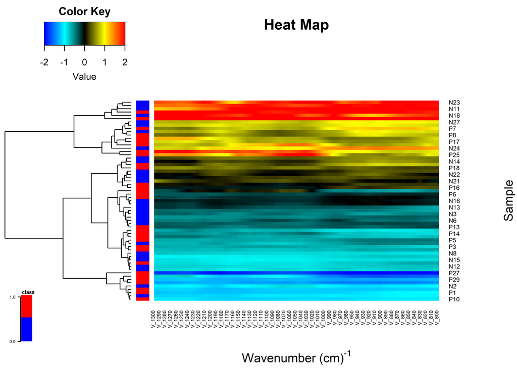

```r
hm <- heatMaps(data=SalivaIR_Avg,
               Outcome="class",
               Scale=TRUE,
               hCluster = "row",
               xlab=expression("Wavenumber (cm)"^"-1"),
               ylab="Sample")
```

```r
par(op)
```

### 1.3.1 The UMAP

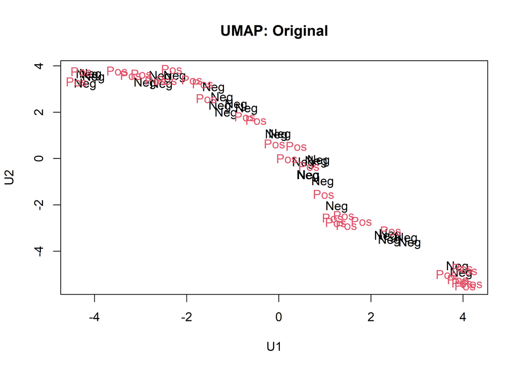

```r
lnames <- c("Neg","Pos")
featnames <- colnames(SalivaIR_Avg)
featnames <- featnames[featnames != "class"]
datasetframe.umap = umap(FRESAScale(SalivaIR_Avg[,featnames])$scaledData,n_components=2)
plot(datasetframe.umap$layout,col=(SalivaIR_Avg$class+1),xlab="U1",ylab="U2",main="UMAP: Original",t='n')
text(datasetframe.umap$layout,labels=lnames[1+SalivaIR_Avg$class],col=(SalivaIR_Avg$class+1))
```

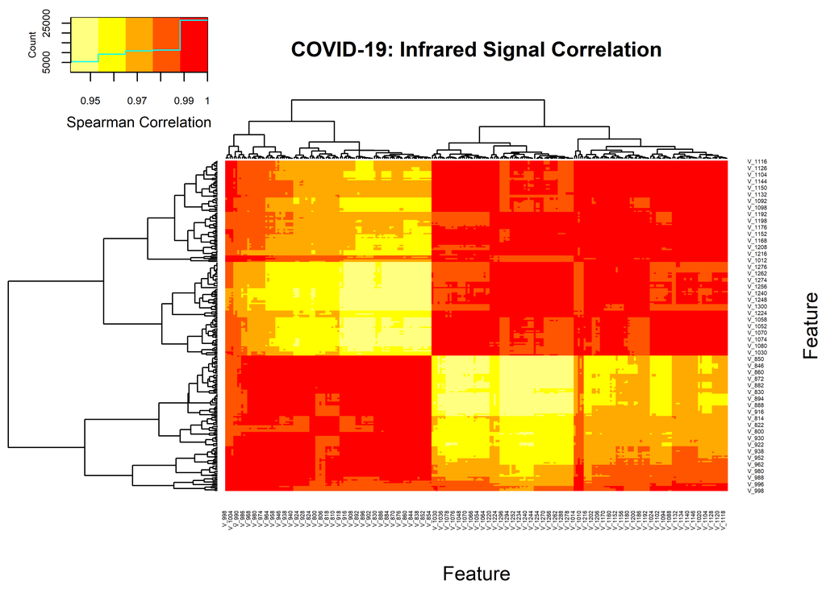

```r
par(cex=0.6,cex.main=0.85,cex.axis=0.7)
cormat <- cor(SalivaIR_Avg[,colnames(SalivaIR_Avg) != "class"],method="spearman")
cormat[is.na(cormat)] <- 0
gplots::heatmap.2(abs(cormat),
                  trace = "none",
#                  scale = "row",
                  mar = c(5,5),
                  col=rev(heat.colors(5)),
                  main = "COVID-19: Infrared Signal Correlation",
                  cexRow = 0.35,
                  cexCol = 0.35,
                  key.title=NA,
                  key.xlab="Spearman Correlation",
                  xlab="Feature", ylab="Feature")
```

```r
par(op)
```

## 1.4 The decorrelation

```r
deIR <- IDeA(SalivaIR_Avg,thr=0.80,verbose = TRUE)
```

Included: 251 , Uni p: 0.0499003 , Uncorrelated Base: 1 , Outcome-Driven Size: 0 , Base Size: 1

1 <R=1.000,w= 1,N= 251>, Top: 3( 71 )1 : 3 : 0.975,<|>Tot Used: 251 , Added: 248 , Zero Std: 0 , Max Cor: 1.000

2 <R=1.000,w= 1,N= 251>, Top: 25( 7 )=2 : 25 : 0.989,<|>Tot Used: 251 , Added: 138 , Zero Std: 0 , Max Cor: 0.999

3 <R=0.999,w= 1,N= 251>, Top: 57( 3 )1 : 57 : 0.975,<|>Tot Used: 251 , Added: 100 , Zero Std: 0 , Max Cor: 0.999

4 <R=0.999,w= 1,N= 251>, Top: 38( 2 )1 : 38 : 0.975,<|>Tot Used: 251 , Added: 55 , Zero Std: 0 , Max Cor: 0.999

5 <R=0.999,w= 1,N= 251>, Top: 13( 1 )1 : 13 : 0.974,<|>Tot Used: 251 , Added: 16 , Zero Std: 0 , Max Cor: 0.995

6 <R=0.995,w= 2,N= 104>, Top: 43( 2 )1 : 43 : 0.948,<|>Tot Used: 251 , Added: 49 , Zero Std: 0 , Max Cor: 1.000

7 <R=1.000,w= 2,N= 104>, Top: 19( 1 )1 : 19 : 0.950,<|>Tot Used: 251 , Added: 20 , Zero Std: 0 , Max Cor: 0.991

8 <R=0.991,w= 2,N= 104>, Top: 10( 1 )1 : 10 : 0.946,<|>Tot Used: 251 , Added: 10 , Zero Std: 0 , Max Cor: 0.993

9 <R=0.993,w= 3,N= 111>, Top: 46( 2 )1 : 46 : 0.897,<|>Tot Used: 251 , Added: 54 , Zero Std: 0 , Max Cor: 0.998

10 <R=0.998,w= 3,N= 111>, Top: 25( 1 )1 : 25 : 0.899,<|>Tot Used: 251 , Added: 27 , Zero Std: 0 , Max Cor: 0.992

11 <R=0.992,w= 3,N= 111>, Top: 7( 1 )1 : 7 : 0.896,<|>Tot Used: 251 , Added: 7 , Zero Std: 0 , Max Cor: 0.895

12 <R=0.895,w= 4,N= 126>, Top: 45( 3 )1 : 45 : 0.800,<|>Tot Used: 251 , Added: 61 , Zero Std: 0 , Max Cor: 0.984

13 <R=0.984,w= 4,N= 126>, Top: 17( 1 )1 : 17 : 0.842,<|>Tot Used: 251 , Added: 18 , Zero Std: 0 , Max Cor: 0.963

14 <R=0.963,w= 4,N= 126>, Top: 9( 1 )1 : 9 : 0.832,<|>Tot Used: 251 , Added: 9 , Zero Std: 0 , Max Cor: 0.964

15 <R=0.964,w= 5,N= 16>, Top: 7( 1 )1 : 7 : 0.800,<|>Tot Used: 251 , Added: 7 , Zero Std: 0 , Max Cor: 0.797

16 <R=0.000,w= 5,N= 16>

[ 16 ], 0.7971747 Decor Dimension: 251 . Cor to Base: 75 , ABase: 1 , Outcome Base: 0

```r
#deIR <- IDeA(SalivaIR_Avg,thr=0.80,relaxed=FALSE,verbose = TRUE)

pander::pander(sum(apply(SalivaIR_Avg,2,var)))
```

*6.47*

```r
pander::pander(sum(apply(deIR,2,var)))
```

*0.288*

```r
pander::pander(entropy(discretize(unlist(SalivaIR_Avg[,colnames(SalivaIR_Avg) != "class"]), 256)))
```

*5.09*

```r
pander::pander(entropy(discretize(unlist(deIR[,colnames(deIR) != "class"]), 256)))
```

*0.791*

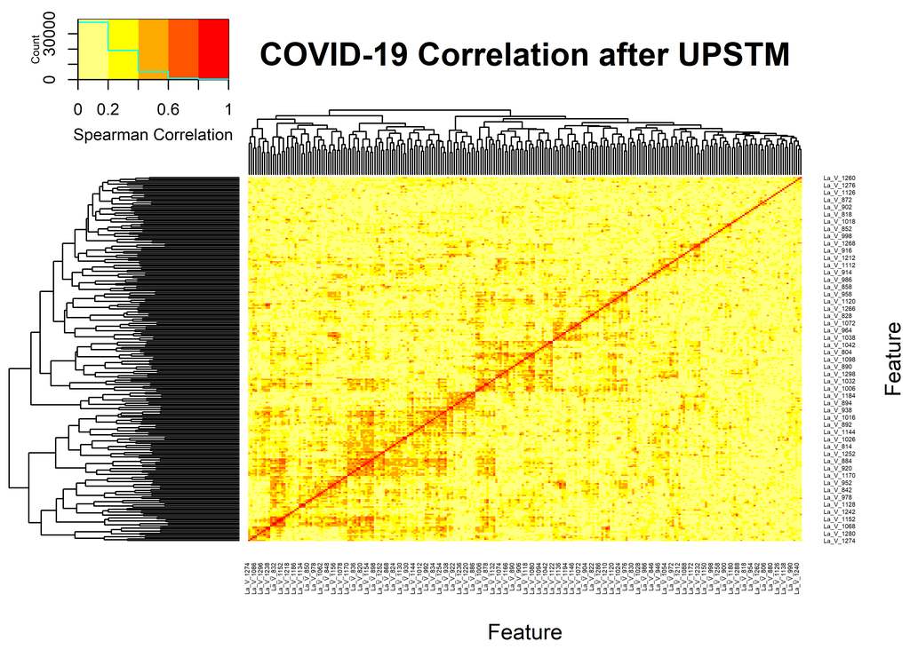

```r
cormat <- cor(deIR[,colnames(deIR) != "class"],method="spearman")
cormat[is.na(cormat)] <- 0
gplots::heatmap.2(abs(cormat),
                  trace = "none",
#                  scale = "none",
                  mar = c(5,5),
                  col=rev(heat.colors(5)),
                  main = "COVID-19 Correlation after UPSTM",
                  cexRow = 0.35,
                  cexCol = 0.35,
                  key.title=NA,
                  key.xlab="Spearman Correlation",
                  xlab="Feature", ylab="Feature")
```

```r
par(op)
```

## 1.5 The heatmap of the decorrelated data

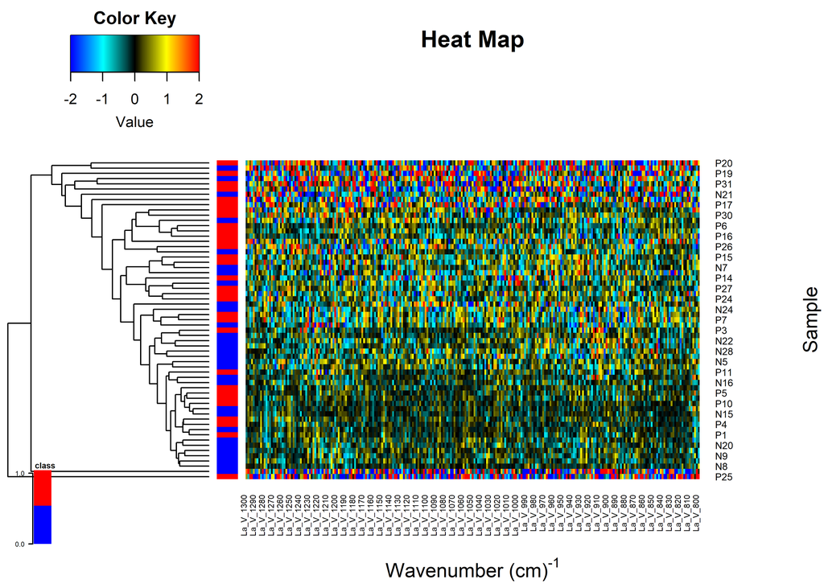

```r
#hm <- heatMaps(data=deIR,Outcome="class",Scale=TRUE,hCluster = "col")
hm <- heatMaps(data=deIR,
               Outcome="class",
               Scale=TRUE,
               hCluster = "row",
               xlab=expression("Wavenumber (cm)"^"-1"),
               ylab="Sample")
```

```r
par(op)
```

### 1.5.1 The decorralted UMAP

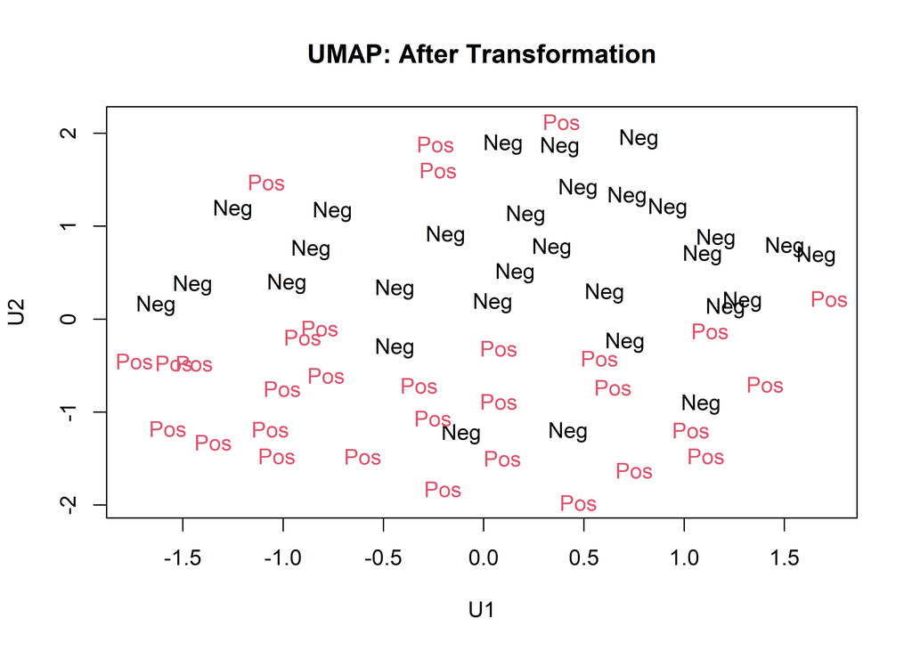

```r
featnames <- colnames(deIR)
featnames <- featnames[featnames != "class"]
datasetframe.umap = umap(FRESAScale(deIR[,featnames])$scaledData,n_components=2)
plot(datasetframe.umap$layout,col=(deIR$class+1),xlab="U1",ylab="U2",main="UMAP: After Transformation",t='n')
text(datasetframe.umap$layout,labels=lnames[1+deIR$class],col=(deIR$class+1))
```

### 1.5.2 The decorrelation matrix

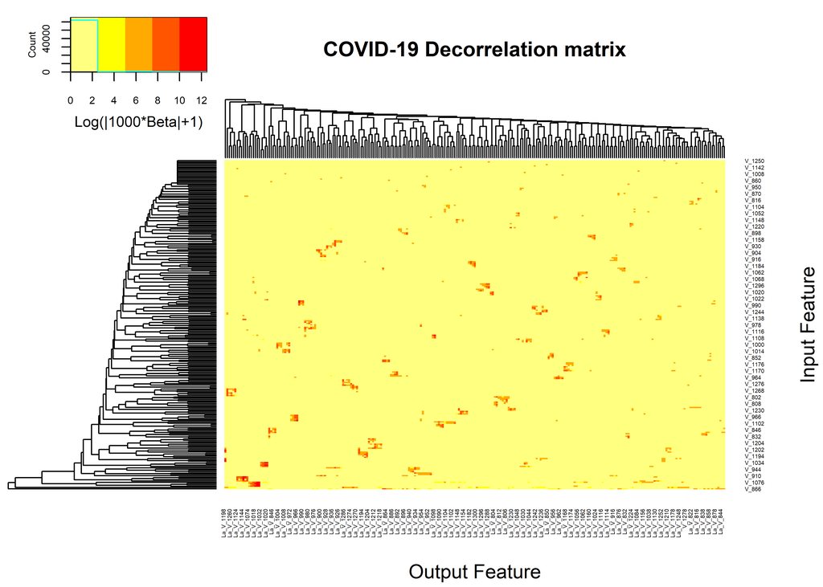

```r
par(cex=0.6,cex.main=0.85,cex.axis=0.7)

UPSTM <- attr(deIR,"UPSTM")
fscores <- attr(deIR,"fscore")
fscores <- fscores[order(-fscores)]
#fscores[fscores>0]

gplots::heatmap.2(log(abs(1000*UPSTM)+1),
                  trace = "none",
#                  scale = "none",
                  mar = c(5,5),
                  col=rev(heat.colors(5)),
                  main = "COVID-19 Decorrelation matrix",
                  cexRow = 0.35,
                  cexCol = 0.35,
                  key.title=NA,
                  key.xlab="Log(|1000*Beta|+1)",
                  xlab="Output Feature", ylab="Input Feature")
```

```r
par(op)
```

### 1.5.3 Plots

```r
par(mfrow=c(2,1),cex=0.8,cex.axis=0.7,cex.main=0.8)

varlist <- colnames(SalivaIR_Avg)[!(colnames(SalivaIR_Avg) %in% "class")]
#varlist <- cbind(varlist,varlist)
#class(varlist)

univar <- uniRankVar(varlist,
               "class~1",
               "class",
               SalivaIR_Avg,
               categorizationType = "Raw",
               type = "LOGIT",
               rankingTest = "AUC",
                uniType = "Binary")
```

100 : V_1102 200 : V_902

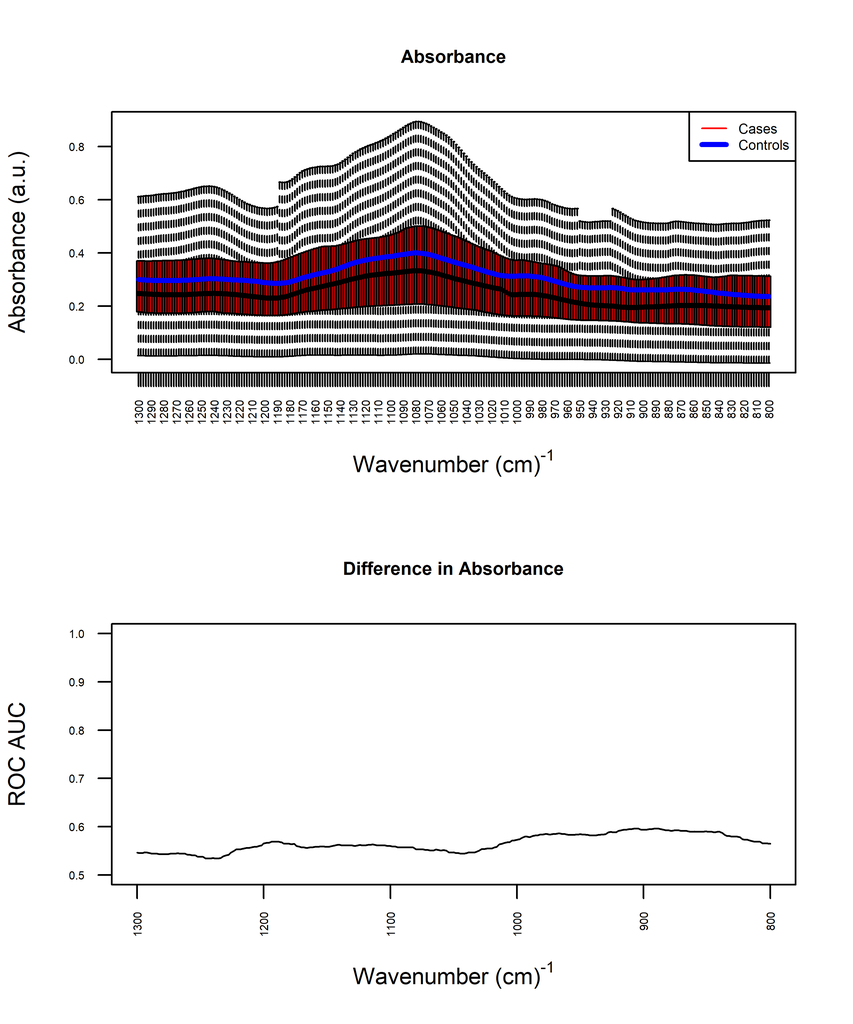

```r
cases <- subset(SalivaIR_Avg,class==1)
cases$class <- NULL
controls <- subset(SalivaIR_Avg,class==0)
controls$class <- NULL
colnames(cases) <- str_remove_all(colnames(cases),"V_")
bpcases <- boxplot(cases,
                   boxwex=1.25,
                   outline = FALSE,
                   col="red",
                   las=2,
                   cex.axis=0.5,
                   ylab="Absorbance (a.u.)",
                   xlab=expression("Wavenumber (cm)"^"-1"))
#bpcontrols <- boxplot(controls,col="blue",outline = FALSE,boxwex=0.25,las=2,add = TRUE,cex.axis=0.5)
lines(apply(controls,2,mean),col="blue",lwd=3)
title("Absorbance")
legend("topright",legend=c("Cases", "Controls"),
       col=c("red", "blue"), lty=1:1,lwd=c(1,3), cex=0.6)

effectSize <- (apply(cases,2,mean)-apply(controls,2,mean))/apply(SalivaIR_Avg[,str_detect(colnames(SalivaIR_Avg),"V_")],2,sd)
wavenumber=as.numeric(str_remove_all(names(effectSize),"V_"))

aucvalue <- univar$orderframe$ROCAUC


wavenumber=as.numeric(str_remove_all(rownames(univar$orderframe),"V_"))
aucvalueRaw <- aucvalue[order(wavenumber)]
wavenumberRaw <- wavenumber[order(wavenumber)]
bpdiff <- plot(wavenumberRaw,aucvalueRaw,las=2,cex.axis=0.5,type="l",
                                  ylab="ROC AUC",
                    xlim = c(1300,800),
                    ylim = c(0.5,1.0),
                   xlab=expression("Wavenumber (cm)"^"-1"))
title("Difference in Absorbance")
```

```r
varlist <- colnames(deIR)[!(colnames(deIR) %in% "class")]
#varlist <- cbind(varlist,varlist)

univarDe <- uniRankVar(varlist,
               "class~1",
               "class",
               deIR,
               categorizationType = "Raw",
               type = "LOGIT",
               rankingTest = "AUC",
                uniType = "Binary")
```

100 : La_V_1102 200 : La_V_902

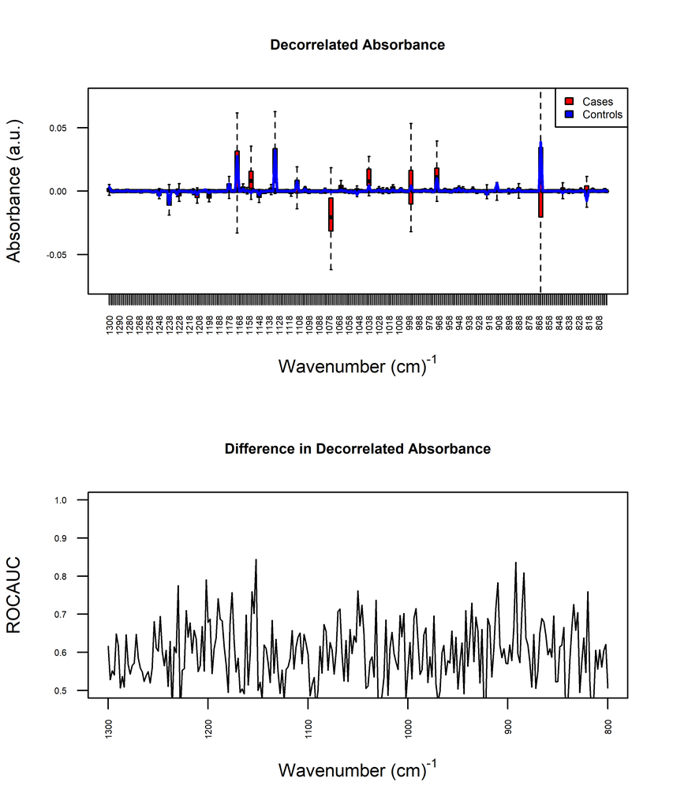

```r
decorfeat <- colnames(deIR)[str_detect(colnames(deIR),"La_")]
parentfeat <- str_remove_all(decorfeat,"La_")
reldecor <- deIR[,decorfeat]
reldecor$class <- SalivaIR_Avg$class
cases <- subset(reldecor,class==1)
cases <- cases[,str_detect(colnames(cases),"La_")]
colnames(cases) <- str_remove_all(colnames(cases),"La_V_")
controls <- subset(reldecor,class==0)
controls <- controls[,str_detect(colnames(controls),"La_")]
colnames(controls) <- str_remove_all(colnames(controls),"La_V_")
bpcases <- boxplot(cases,
                   boxwex=2.0,
                   outline = FALSE,
                   col="red",
                   las=2,
                   cex.axis=0.5,
                   ylim=c(-0.075,0.075),
                   ylab="Absorbance (a.u.)",
                   xlab=expression("Wavenumber (cm)"^"-1"))

#bpcontrols <- boxplot(controls,col="blue",ylim=c(-0.075,0.075),outline = FALSE,boxwex=1.25,las=2,add = TRUE,cex.axis=0.5)
lines(apply(controls,2,mean),col="blue",lwd=2)
#lines(controls,col="blue",ylim=c(-0.075,0.075))
title("Decorrelated Absorbance")
legend("topright",legend=c("Cases", "Controls"),
        fill=c("red", "blue"),
       cex=0.6)





effectSize <- (apply(cases,2,median)-apply(controls,2,median))/apply(reldecor[,str_detect(colnames(reldecor),"La_")],2,IQR)
wavenumber=as.numeric(str_remove_all(names(effectSize),"La_V_"))

aucvalue <- univarDe$orderframe$ROCAUC
depcvalue <- univarDe$orderframe$WilcoxRes.p

names(aucvalue) <- rownames(univarDe$orderframe)
#plot(aucvalue[names(fscores)],fscores)


wavenumber=str_remove_all(rownames(univarDe$orderframe),"La_V_")
#wavenumber=str_remove_all(wavenumber,"Ba_V_")
wavenumber=as.numeric(str_remove_all(wavenumber,"V_"))
aucvalueDe <- aucvalue[order(wavenumber)]
depcvalue <- depcvalue[order(wavenumber)]
wavenumberDe <- wavenumber[order(wavenumber)]

bpdiff <- plot(x=wavenumberDe,y=aucvalueDe,las=2,cex.axis=0.5,type="l",
                                   xlim = c(1300,800),
                                  ylab="ROCAUC",
                   ylim = c(0.5,1.0),
                   xlab=expression("Wavenumber (cm)"^"-1"))
title("Difference in Decorrelated Absorbance")
```

```r
par(op)
```

### 1.5.4 Comparing Univariate ROC AUC

```r
par(cex=0.8)
varlist <- colnames(SalivaIR_d2)[!(colnames(SalivaIR_d2) %in% "class")]
#varlist <- cbind(varlist,varlist)
pthr <- 0.10/(ncol(SalivaIR)-1)

univarD2 <- uniRankVar(varlist,
               "class~1",
               "class",
               SalivaIR_d2,
               categorizationType = "Raw",
               type = "LOGIT",
               rankingTest = "AUC",
                uniType = "Binary")
```

100 : DD_1100 200 : DD_900

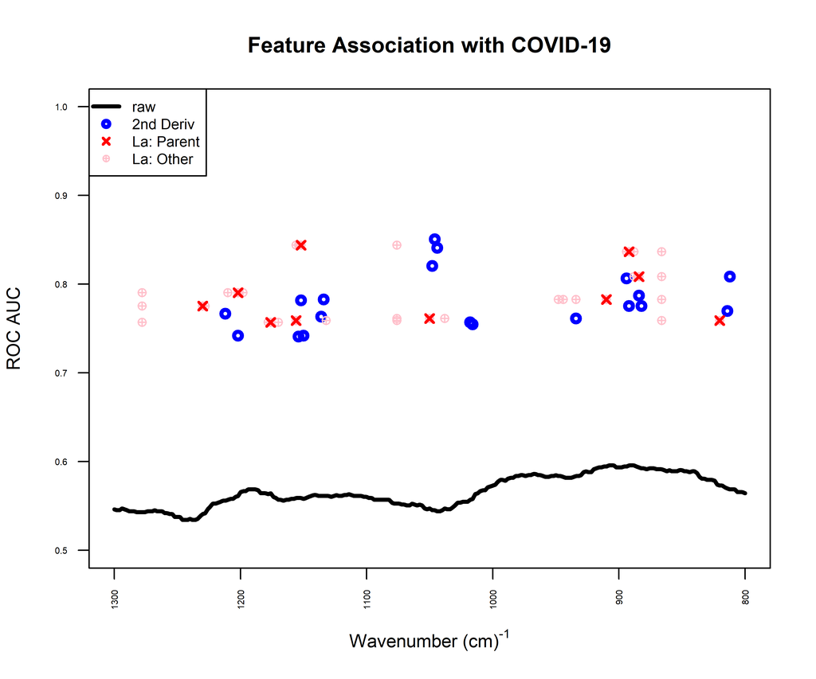

```r
aucvalue <- univarD2$orderframe$ROCAUC
names(aucvalue) <- rownames(univarD2$orderframe)
pwilvalue <- univarD2$orderframe$FRes.p


wavenumber=as.numeric(str_remove_all(rownames(univarD2$orderframe),"DD_"))
aucvalueDD <- aucvalue[order(wavenumber)]
wavenumberDD <- wavenumber[order(wavenumber)]
pwilvalue <- pwilvalue[order(wavenumber)]


bpdiff <- plot(x=wavenumberRaw,y=aucvalueRaw,
               las=2,
               cex.axis=0.5,
               type="l",
               lwd=3,
                xlim=c(1300,800),
                ylim=c(0.5,1.0),
               ylab="ROC AUC",
               xlab=expression("Wavenumber (cm)"^"-1"))
title("Feature Association with COVID-19")

valroc <- pwilvalue < pthr
points(wavenumberDD[valroc],aucvalueDD[valroc],col="blue",lwd=3)

#bpdiff <- plot
valroc <- depcvalue < pthr

dc <- getLatentCoefficients(deIR)
for (dename in names(dc))
{
  wave <- as.numeric(str_remove(dename,"La_V_"))
  if (wave %in% wavenumberDe[valroc])
  {
    for (asfeat in names(dc[[dename]]))
    {
      points(x=as.numeric(str_remove_all(asfeat,"V_")),
               y=univarDe$orderframe[dename,"ROCAUC"],col="pink",pch=10)
    }
  }
}

points(x=wavenumberDe[valroc],
               y=aucvalueDe[valroc],col="red",pch=4,lwd=2)

legend("topleft",legend=c("raw", "2nd Deriv","La: Parent","La: Other"),
       col=c("black", "blue","red","pink"), lty=c(1,0,0,0),lwd=c(3,3,2,1),pch=c(-1,1,4,10), cex=0.8)
```

### 1.5.5 Final Table

```r
univariate_columns <- c("caseMean","caseStd","controlMean","controlStd","controlKSP","ROCAUC","ZGLM","FRes.p")

pwilvalue <- univarDe$orderframe$FRes.p
valroc <- pwilvalue < pthr

finalTable <- univarDe$orderframe[valroc,univariate_columns]

theFormulas <- dc[rownames(finalTable)]
deFromula <- character(length(theFormulas))
names(deFromula) <- rownames(finalTable)

dx <- names(deFromula)[1]
for (dx in names(deFromula))
{
  coef <- theFormulas[[dx]]
  cname <- names(theFormulas[[dx]])
  names(cname) <- cname
  for (cf in names(coef))
  {
    if (cf != dx)
    {
      if (coef[cf]>0)
      {
        deFromula[dx] <- paste(deFromula[dx],
                               sprintf("+ %5.3f*%s",coef[cf],cname[cf]))
      }
      else
      {
        deFromula[dx] <- paste(deFromula[dx],
                               sprintf("%5.3f*%s",coef[cf],cname[cf]))
      }
    }
  }
}
orgnamez <- rownames(finalTable)
#orgnamez <- str_remove_all(orgnamez,"Ba_")
orgnamez <- str_remove_all(orgnamez,"La_")
finalTable$DecorFormula <- deFromula[rownames(finalTable)]
finalTable$fscores <- fscores[rownames(finalTable)]

pander::pander(finalTable)
```

[output not shown]